# Tutorial 6: Cross-Validation and Bootstrap

Feb 22, 2018

In this tutorial, we will explore Cross-Validation and the Bootstrap.

One major task of machine learning is to evaluate the expected performance of a learning algorithm. In general, we choose a loss function $L$ (e.g. $L_2$ loss, 0-1 loss, binomial deviance), when the outcome $Y$ and predictors $X$ come from an unknown distribution $p(Y, X)$, we want to estimate the expected loss for any prediction $\hat y =\hat{f}(\mathbf{x})$,
$$\mbox{test error of }\hat{f}=\mathbb{E} [L(Y, \hat{f}(X)].$$
It is crucial especially when there are tuning parameters in the model– we want to select the optimal model that leads to the lowest test error.

One method we can use is to split the data into training set and an independent test set, and use the average loss on the test set as an unbiased estimator of test error. But what if we have an extra model-selection procedure? Clearly, we cannot use the same data set for both model-selection and model-assessment!

### Model selection

In order to evaluate the performance of different models and choose the optimal one, we randomly split data into three sets: a training set, a validation set and a test set.

For example, let’s consider a regression problem where we have $n=50$ observations and $d=30$ predictors, while most of them are not predictive. To adapt to the sparsity nature of the model, we use the lasso regression with a tuning parameter $\lambda$. We want to choose the optimal $\lambda$, and estimate the test error.

To this end, we carry out K-fold cross-validation. We first set aside the test set that contains 30% of the data. Then split the remaining data into K blocks. Use each block in turn as the validation set and perform cross-validation and average the results over all K combinations.

We will use the `R` package `glmnet`.

```r
library(glmnet)
```

The data is generated from the following model
$$Y = \sum_{j=1}^d \beta_j X_j Z_j + \epsilon, \quad \epsilon \sim \mathcal{N}(0, 1),$$
where $Z_j$’s are Bernoulli random variables with parameter 0.1 and $\beta_j$’s are generated from the uniform distribution on $[-3, 3]$. We use the following code generate 50 observation.

```r
set.seed(123)
d=30
n=50
x=matrix(rnorm(d*n,  1,1), n,d)
beta=rbinom(d,size=1,prob=0.1)*runif(d,-3, 3)
eps=rnorm(n,0,1)
y=x%*%beta+eps
```

We fist set aside a test set, which contains 30% data points.

```r
train = sample(1:n, n*0.7)
test= c(1:n)[-train]
ytest = y[test]

xtrain=x[train,]
ytrain=y[train]
```

This function is to calculate the average loss of a model on a data set

```r
cv_error=function(fitted_model,newy,newx){
  pred <- predict(fitted_model, newx = newx)
  error=colMeans((pred-newy)^2)
  return(error)
}
```

The following function carries out $K$-fold cross-validation for the lasso

```r
lasso_cv=function(k, lambda){
  nlambda = length(lambda)
  validation_error_mat=matrix(NA,k,nlambda)
  for( j in 1:k){
    validation_index=c((j-1)*(length(train)%/%k)+1:(length(train)%/%k)) ## the training data has already been shuffled.
    train_index=c(1:length(train))[-validation_index]
    lasso.mod = glmnet(xtrain[train_index,], ytrain[train_index], alpha = 1, lambda=lambda)
    validation_error_mat[j,]=cv_error(fitted_model=lasso.mod,newy=ytrain[validation_index],newx= if
                                      (length(validation_index)==1){ t(xtrain[validation_index,]) } else
                                      {xtrain[validation_index,]} )
  }
  return(validation_error_mat)
}
```

The following function is for the visualision of cross-validation result.

```r
lasso_cv_graph=function(legend_1,k,lambda, tit){
  k_fold_cv=lasso_cv(k, lambda)
  validation_error=apply(k_fold_cv, 2,mean)
  validation_error_sd=apply(k_fold_cv, 2,sd)/sqrt(k)
  lasso.mod <- glmnet(x[train,], y[train], alpha = 1, lambda = lambda)
  test_error=cv_error(lasso.mod,newy=ytest,newx= x[test,])
  best_lambda=which.min(validation_error)
  print("The optimal lambda that minimizes CV error is" )
  print(lambda[best_lambda])
  print("The 'rule of thumb' lambda is" )
  print(max(lambda[ validation_error<=(validation_error[best_lambda]+ validation_error_sd[best_lambda])]))
  plot(log(lambda),validation_error ,ylim=range(validation_error-validation_error_sd,
                                                validation_error+validation_error_sd,
                                                test_error),pch=20,cex=0.5,col='blue',ylab="MSE",main =tit)
  lines(log(lambda),validation_error,col='blue' )
  lines(log(lambda),test_error)
  for( i in 1:nlambda){
    lines(x=rep(log(lambda)[i],2),
          y=c(validation_error[i]-validation_error_sd[i],
              validation_error[i]+validation_error_sd[i]),lwd=0.3,col='blue')
    }
  legend("topleft", col=c("blue", 1), lwd=2, legend=c(legend_1, "test error"))
  points( log(lambda)[best_lambda],validation_error[best_lambda],col=2 )
}
```

For example, we perform 10-fold CV.

```
## [1] "The optimal lambda that minimizes CV error is"
## [1] 0.1400834
## [1] "The 'rule of thumb' lambda is"
## [1] 0.3433635
```

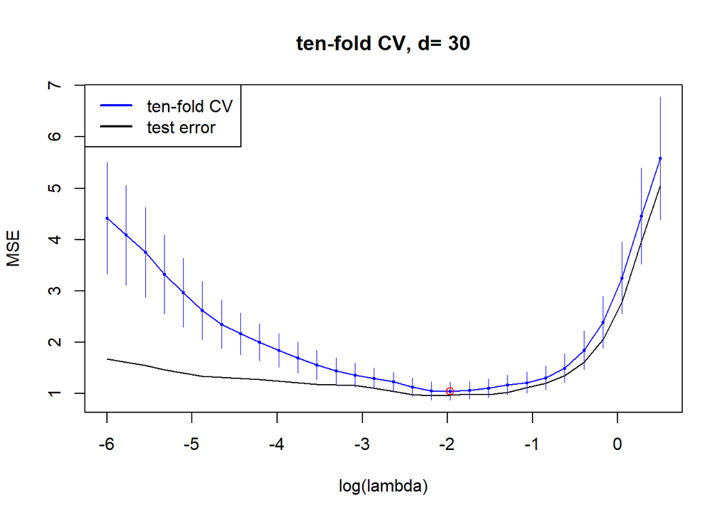

```r
nlambda=30
lambda=exp(seq(0.5, -6, length = nlambda))
lasso_cv_graph("ten-fold CV", 10, lambda, tit=paste("ten-fold CV, d=",d))
```

### leave-one-out (LOO) CV.

When $K=n$, each validation set is of size 1, this is also termed as leave-one-out (LOO) CV.

```
## [1] "The optimal lambda that minimizes CV error is"
## [1] 0.1119553
## [1] "The 'rule of thumb' lambda is"
## [1] 0.3433635
```

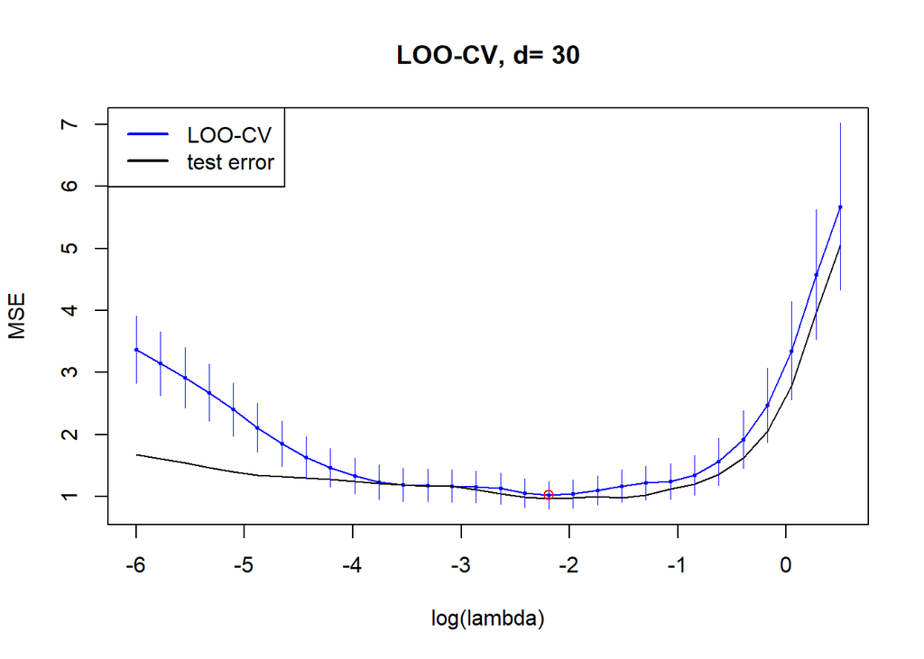

```r
lasso_cv_graph("LOO-CV", length(train),lambda,tit=paste("LOO-CV, d=",d))
```

## How to choose K?

There is no general rule to choose $K$, as it depends on the problem. In $K$-fold CV with a relatively small $K$, we train the model on less data than what is available. This introduces bias into the estimates of test error. In LOO-CV, the training samples highly resemble each other. This increases the variance of the test error estimate.

In the previous example, LOO and 10-fold CV have similar result. But if we increases the dimension to make the learning curve steeperï¼then the bias of 10-fold CV estimation error becomes significant.

```
## [1] "The optimal lambda that minimizes CV error is"
## [1] 0.0003354626
## [1] "The 'rule of thumb' lambda is"
## [1] 0.1664428
```

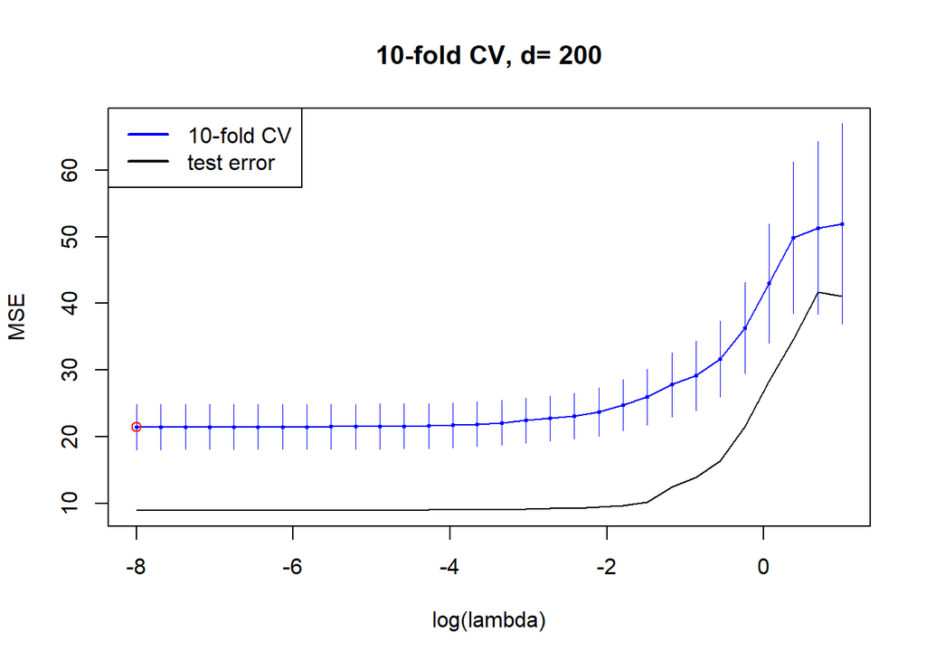

```r
set.seed(123)
d=200
n=50
x=matrix(rnorm(d*n,  1,1), n,d)
beta=rbinom(d,size=1,prob=0.1)*runif(d,-3, 3)
eps=rnorm(n,0,1)
y=x%*%beta+eps
train = sample(1:n, n*0.7)
test= c(1:n)[-train]
ytest = y[test]
nlambda=30
lambda=exp(seq(1, -8, length = nlambda))
xtrain=x[train,]
ytrain=y[train]
lasso_cv_graph("10-fold CV", 10, lambda, tit=paste("10-fold CV, d=",d))
```

```
## [1] "The optimal lambda that minimizes CV error is"
## [1] 0.0003354626
## [1] "The 'rule of thumb' lambda is"
## [1] 0.1664428
```

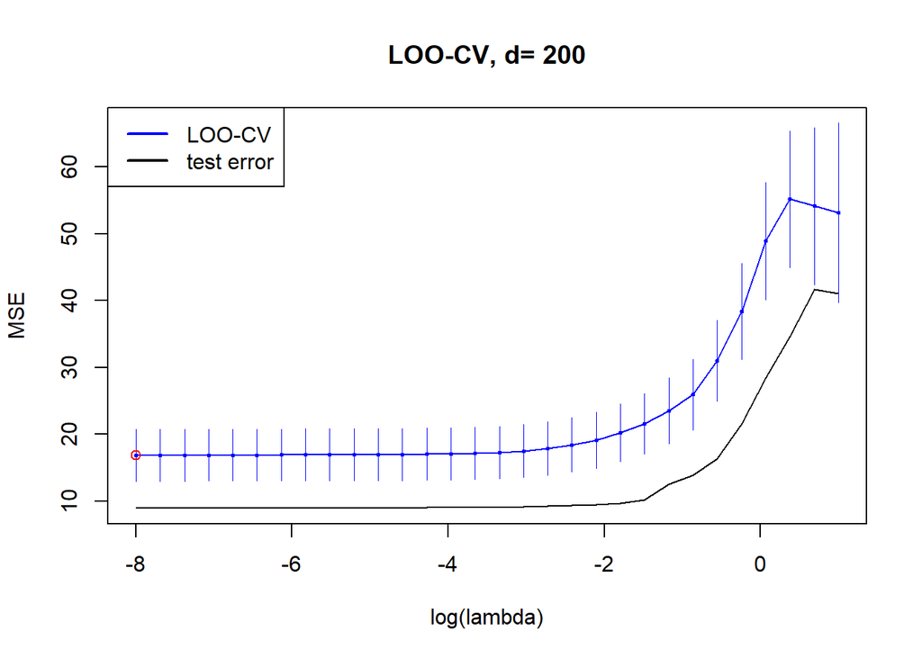

```r
lasso_cv_graph("LOO-CV", length(train), lambda, tit=paste("LOO-CV, d=",d))
```

# The Bootstrap

```r
library(boot)
summary(lm(cost~.,data = nuclear)  )
```

```
##
## Call:
## lm(formula = cost ~ ., data = nuclear)
##
## Residuals:
##      Min       1Q   Median       3Q      Max
## -128.608  -46.736   -2.668   39.782  180.365
##
## Coefficients:
##               Estimate Std. Error t value Pr(>|t|)
## (Intercept) -8.135e+03  2.788e+03  -2.918 0.008222 **
## date         1.155e+02  4.226e+01   2.733 0.012470 *
## t1           5.928e+00  1.089e+01   0.545 0.591803
## t2           4.571e+00  2.243e+00   2.038 0.054390 .
## cap          4.217e-01  8.844e-02   4.768 0.000104 ***
## pr          -8.112e+01  4.077e+01  -1.990 0.059794 .
## ne           1.375e+02  3.869e+01   3.553 0.001883 **
## ct           4.327e+01  3.431e+01   1.261 0.221008
## bw          -8.238e+00  5.188e+01  -0.159 0.875354
## cum.n       -6.989e+00  3.822e+00  -1.829 0.081698 .
## pt          -1.925e+01  6.367e+01  -0.302 0.765401
## ---
## Signif. codes:  0 '***' 0.001 '**' 0.01 '*' 0.05 '.' 0.1 ' ' 1
##
## Residual standard error: 82.83 on 21 degrees of freedom
## Multiple R-squared:  0.8394, Adjusted R-squared:  0.763
## F-statistic: 10.98 on 10 and 21 DF,  p-value: 2.844e-06
```

But the p-value itself is noisy, particularly we have only a few observations. What is the distribution of those p-values?

We then run the bootstrap on the p-value estimates:

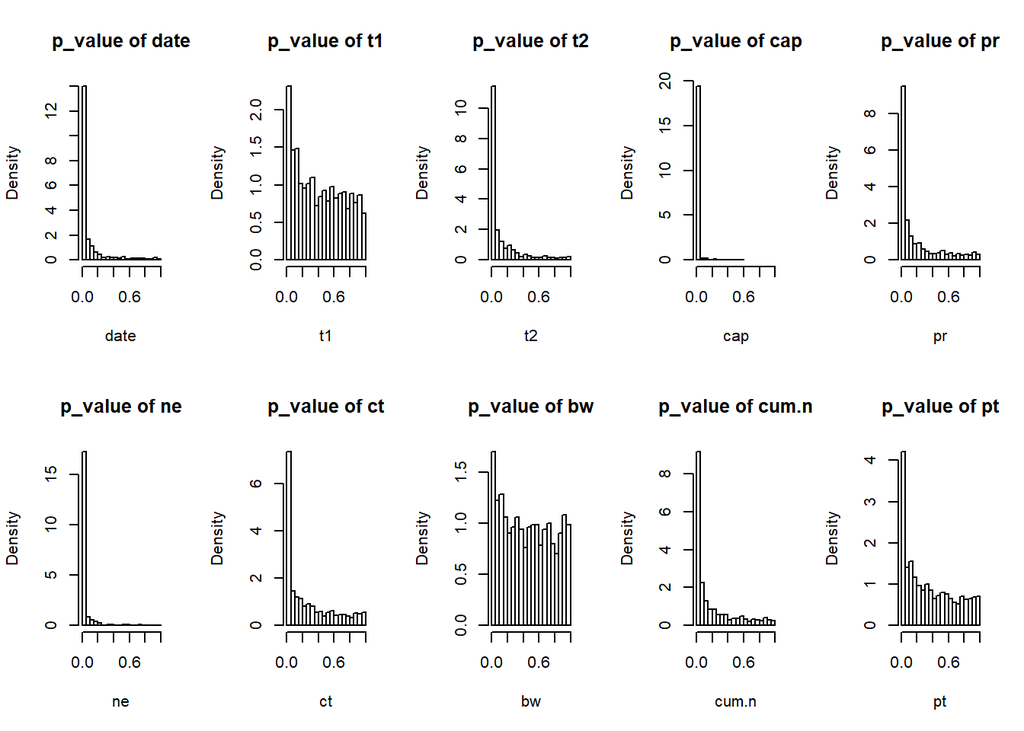

```r
set.seed(123)
variable_name=names(nuclear)[-1]
p_v_estimate = function(data, indices){
  d = data[indices, ]
  l = lm(cost~., data = d)
  p_v =c( summary(l)$coefficients[-1,4] )
  p_v_arg=rep(NA, length(variable_name))
  for(i in 1:length(variable_name))
    if( sum(names( p_v)==variable_name[i])  >=1)
      p_v_arg[i]=p_v[which(names( p_v)==variable_name[i]) ]
  return(p_v_arg)
}
results = boot(data = data.frame( as.matrix(nuclear)), statistic = p_v_estimate, R = 1000)
par(mfrow=c(2,5))
 for(i in 1:10)
 {
   hist(results$t[,i],  main=paste("p_value of", names(nuclear)[i+1] ),xlim=c(0,1) ,prob=T, breaks=20, xlab = names(nuclear)[i+1])
   #abline(v=0.05,col=2)
 }
```

We can also obtain the bootsrap estimate of the variance of regression coefficients:

```r
set.seed(123)
coef_estimate = function(data, indices){
  d = data[indices, ]
  l = lm(cost~., data = d)
  p_v =c( summary(l)$coefficients[-1,1] )
  p_v_arg=rep(NA, length(variable_name))
  for(i in 1:length(variable_name))
    if( sum(names( p_v)==variable_name[i])  >=1)
      p_v_arg[i]=p_v[which(names( p_v)==variable_name[i]) ]
  return(p_v_arg)
}
print( boot(data = data.frame( as.matrix(nuclear)), statistic = coef_estimate, R = 1000))
```

```
##
## ORDINARY NONPARAMETRIC BOOTSTRAP
##
##
## Call:
## boot(data = data.frame(as.matrix(nuclear)), statistic = coef_estimate,
##     R = 1000)
##
##
## Bootstrap Statistics :
##        original      bias    std. error
## t1*  115.483182 -0.08975471  63.3446775
## t2*    5.928437  0.41652399  12.8858036
## t3*    4.570921  0.37143847   3.1022225
## t4*    0.421648 -0.01725226   0.1199543
## t5*  -81.121120  4.31215505  57.2997340
## t6*  137.450223 -4.91974013  52.4472508
## t7*   43.273270 -0.16818232  47.4804135
## t8*   -8.238443 -3.47844425  60.6424711
## t9*   -6.988608  0.90592307   6.2320482
## t10* -19.247631 -4.47454364  96.5764560
```

## Discussion:

1. The corss-validation can also contain tunning parameter, for example, the number of folds K. How can we use corss-validation to choose K?
2. The bootstap estimate also contains uncertainity. How can we quantify that uncertainity? Can we bootstrap the bootstraped-standard-error?